# Week 4 solutions

## What was the task?

Let’s remind ourselves of the task:

> Please draw a ridgeline plot of the prices of a Big Mac in each country in the world, expressed as price in dollars as a fraction of GDP per head in dollars in each of those countries, sorted highest-to-lowest.

In order to do that, let’s get set up, by loading some packages and some data.

```r
library(tidyverse)
library(ggridges)
library(lubridate)

maccas <- read.csv("https://bit.ly/bigmac-data-csv")
```

## Making some variables

This question requires you to generate two variables from the maccas dataset:

1. The price of a Big Mac in dollars – we showed you this in the lab. Divide the price of a Big Mac in local currency (local_price) by the exchange rate (dollar_ex); in my example I’ve called this variable **price_dollars**
2. The price in dollars as a percentage of GDP. So we have to divide the first variable we’ve generated (price_dollars) by GDP_dollar; in my example I’ve called this second variable **GDP_percent**

If you’re making *two* new variables, you can either run two separate mutate commands, or you can run a single mutate command where you make two new variables, separated by commas.

To run two separate mutate commands, you could do this:

```r
maccas %>%
  mutate(price_dollars = local_price / dollar_ex) %>%
  mutate(GDP_percent = price_dollars/GDP_dollar) %>%
  drop_na(price_dollars, GDP_percent)
```

To run a single mutate command where you make two new variables, you could do this:

```r
maccas %>%
  mutate(price_dollars = local_price / dollar_ex,
         GDP_percent = price_dollars/GDP_dollar) %>%
  drop_na(price_dollars, GDP_percent)
```

OK, so our data now has the key variable we need. Let’s use it to make a first graph:

## Making an initial graph

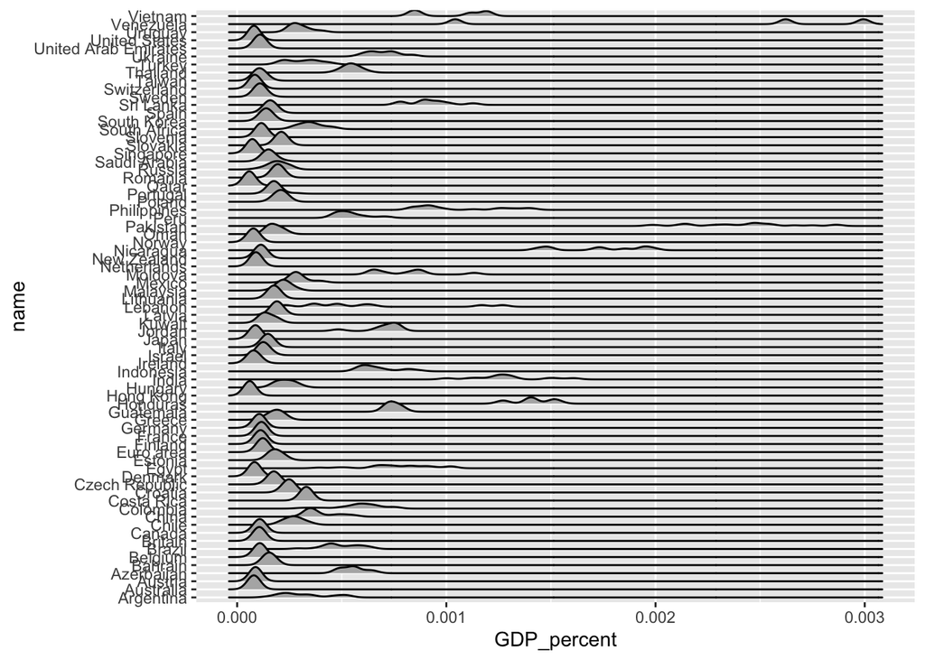

```r
maccas %>%
  mutate(price_dollars = local_price / dollar_ex,
         GDP_percent = price_dollars/GDP_dollar) %>%
  drop_na(price_dollars, GDP_percent) %>%
  ggplot() +
  aes(x = GDP_percent,
      y = name) +
  geom_density_ridges()
```

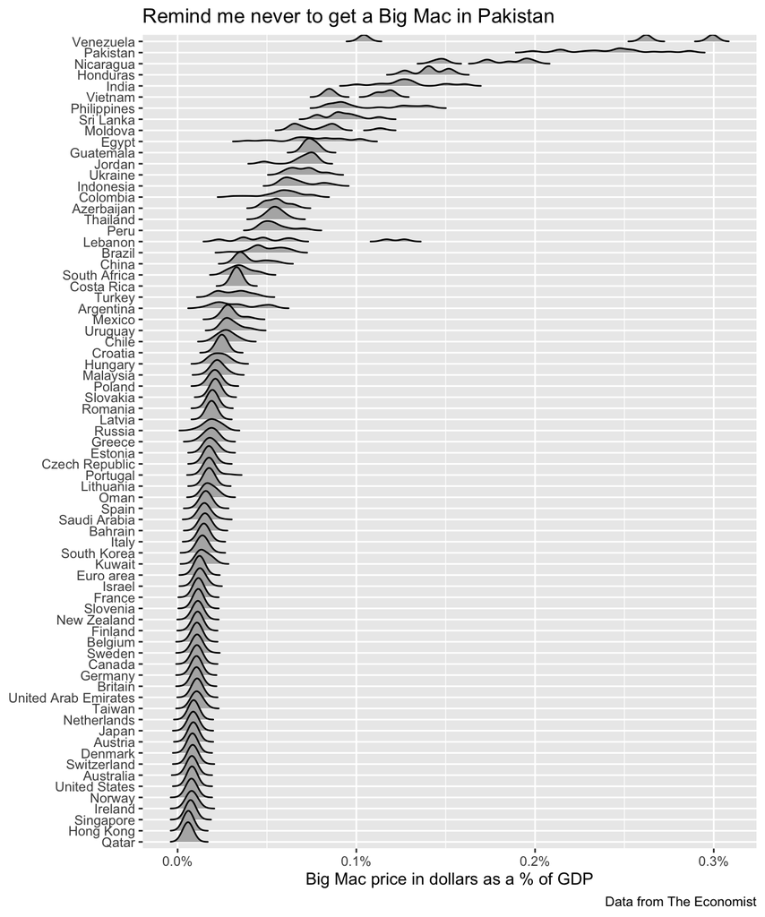

```r
maccas %>%
  mutate(price_dollars = local_price / dollar_ex,
         GDP_percent = price_dollars/GDP_dollar) %>%
  drop_na(price_dollars, GDP_percent) %>%
  ggplot() +
  aes(x = GDP_percent,
      y = fct_reorder(name, GDP_percent)) +
  geom_density_ridges(rel_min_height = 0.001) +
  scale_x_continuous(labels = scales::percent) +
  labs(x = "Big Mac price in dollars as a % of GDP", y = NULL,
       title = "Remind me never to get a Big Mac in Pakistan",
       caption = "Data from The Economist")
```

There’s one new thing here: I’ve specified that I want the scale on the x-axis to be percent, rather than scientific notation. I don’t expect you to have done this, don’t worry!

If you’re wondering why we no longer have the intrusive black lines that run all the way to the end of the plot, it is because of the rel_min_height = 0.001 argument that we added to the geom_density_ridges function. You can find out more about the argument by checking the help documentation for the geom by running: ?geom_density_ridges

# Week 3 Group Task Feedback